# Nigeria Mpox Analysis (2021 - 2025)

Stephen Ojo

2026-03-14

## **Section 1 - People (Demographics & Host Characteristics)**

This section of the report focuses on the **“Person”** aspect of the epidemiological triad. We aim to describe the demographic characteristics of the suspected and confirmed Mpox cases to identify vulnerable populations and patterns of susceptibility.

## 1. Demographic Summary

First, we generate a summary table to understand the central tendencies (Mean, Median) and the spread (Min, Max) of the age distribution across different test results. This provides a high-level overview of the burden of disease.

Summary Statistics by Test Result

| final_result_interpretation | Count | Mean_Age | Median_Age | Min_Age | Max_Age | Percent_of_Total |
| --- | --- | --- | --- | --- | --- | --- |
| Inconclusive | 144 | 19.5 | 17 | 1 | 72 | 3.9 % |
| Negative | 3025 | 19.8 | 17 | 0 | 96 | 82.3 % |
| Positive | 506 | 26.5 | 27 | 0 | 72 | 13.8 % |

**Interpretation:** The table above highlights the total volume of tests processed and the positivity breakdown. Pay close attention to the Mean_Age and Median_Age of the Positive group compared to the Negative group.

## 2. Age Distribution Analysis

This analysis acts as a demographic lens, bringing into focus exactly which age groups the virus targets so we can distinguish the truly vulnerable from the merely suspected.

### A. Histogram of Age

This histogram shows the frequency of cases across age groups, color-coded by the test result.

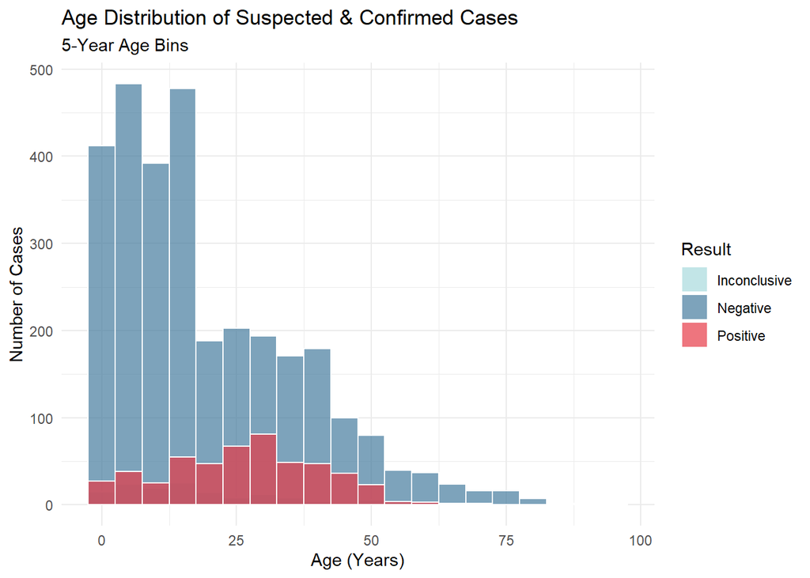

**Chart Analysis & Discovery:** The visual distribution reveals a striking divergence between the population being tested and the population actually affected by Mpox:

**1. High Suspicion in Pediatrics (0–15 Years):**

- The tallest overall bars are observed in the **5–15 year age groups**. This indicates that children generate the highest volume of suspected case alerts and sample collection.
- However, the vast majority of these bars are Blue (Negative). This suggests a high rate of “false alarms,” likely due to clinical confusion with other common childhood rash illnesses (such as Chickenpox/Varicella).

**2. Confirmed Burden in Young Adults (20–40 Years):**

- The Red (Positive) portion of the bars becomes significantly more prominent starting at age 20.
- The peak burden of confirmed Mpox cases is concentrated in the 25–40 year age bracket.
- While the total number of samples collected for this demographic is lower than for children, the positivity rate is much higher.

### B. Boxplot Comparison

Moving beyond the broad distribution seen in the histogram, the boxplot sharpens our focus, allowing us to statistically confirm if the ‘typical’ positive patient is distinctly older or younger than the general tested population.

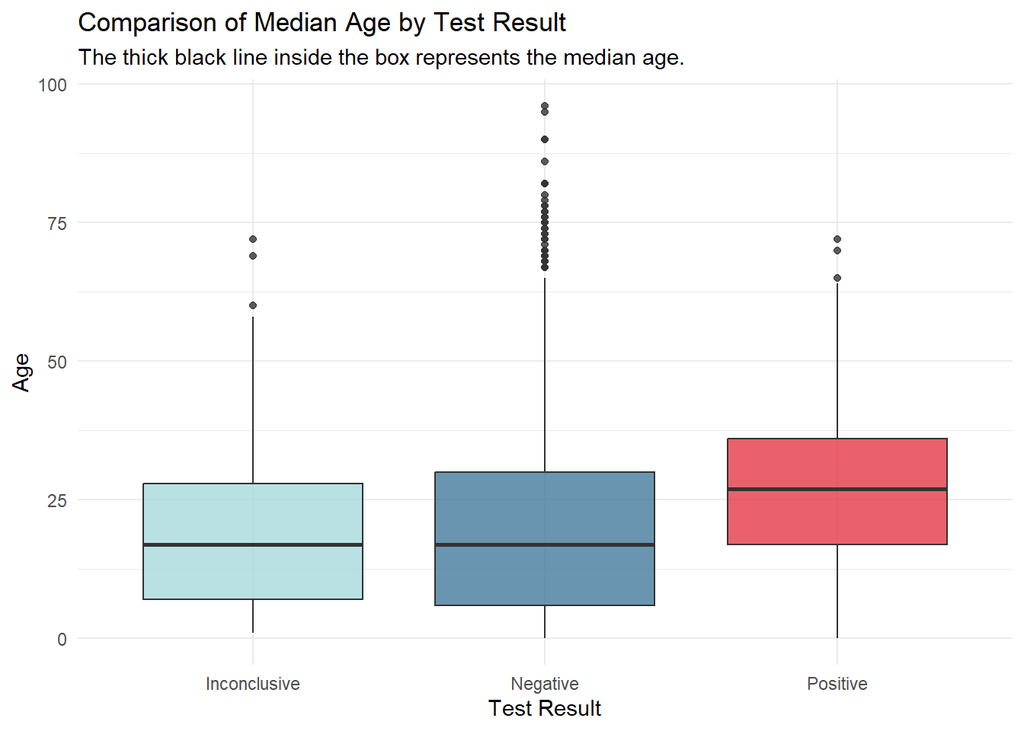

**Chart Analysis & Interpretation:** The boxplot provides a clear statistical confirmation of the age discrepancy observed in the histogram:

**1. Shift in Median Age:**

- The median age (thick black line) for **Positive cases (Red)** is distinctly higher, hovering around **27–28 years**.
- In contrast, the median age for **Negative cases (Dark Blue)** is significantly lower, approximately **17–18 years**.
- This ~10-year gap in median age strongly suggests that the clinical presentation in children often mimics Mpox but results in a negative test (likely Varicella or other pediatric rashes), whereas the true pathology is centered in young adulthood.

**2. Interquartile Range (The Box):**

- The “middle 50%” of the confirmed cases (the Red box) is tightly clustered between **18 and 36 years**. This is the core demographic driving the outbreak.
- The Negative group has a much lower floor, extending down to early childhood, reflecting the high volume of pediatric samples that turn out to be non-cases.

**3. Outliers (The Dots):**

- The Negative group displays a significant number of **outliers in the elderly population (65+)**. This indicates that while surveillance is capturing older individuals with rash symptoms, they are rarely testing positive for Mpox in this outbreak context.

## 3. Gender Analysis

Here we analyze whether sex is a factor in infection rates. This helps us understand if the virus is spreading more in one gender, which could relate to behavioral or occupational exposures.

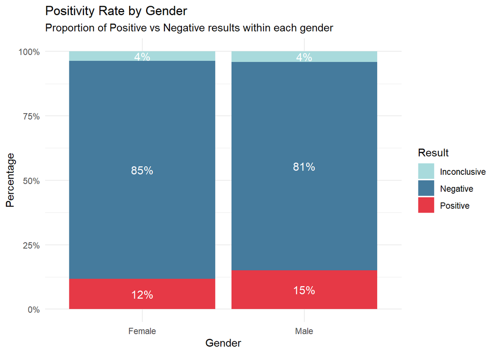

**Chart Analysis & Interpretation:** The stacked bar chart compares the proportion of test outcomes between genders:

**1. Male Predominance in Positivity:**

- **Males** show a higher positivity rate at **15%**, compared to **Females** at **12%**.
- While the difference is not extreme (a 3 percentage point gap), it indicates that male suspects are slightly more likely to be true Mpox cases than female suspects. This aligns with historical patterns of Mpox transmission, which often show a male skew.

**2. High Negative Rate Across Both Groups:**

- The vast majority of suspected cases for both genders tested **Negative (81% for Males, 85% for Females)**.
- This reinforces the earlier finding that surveillance is casting a “wide net,” capturing many non-Mpox rash illnesses in both men and women.

**3. Inconclusive Results:**

- Both groups have a stable 4% inconclusive rate. This suggests that sample quality issues (which typically cause inconclusive results) are evenly distributed and not biased by gender.

## 4. The Age-Sex Pyramid

By projecting age and gender onto a single chart, the Population Pyramid reveals the demographic structure of the outbreak. This allows for rapid detection of vulnerable subgroups that a simple bar chart might miss.

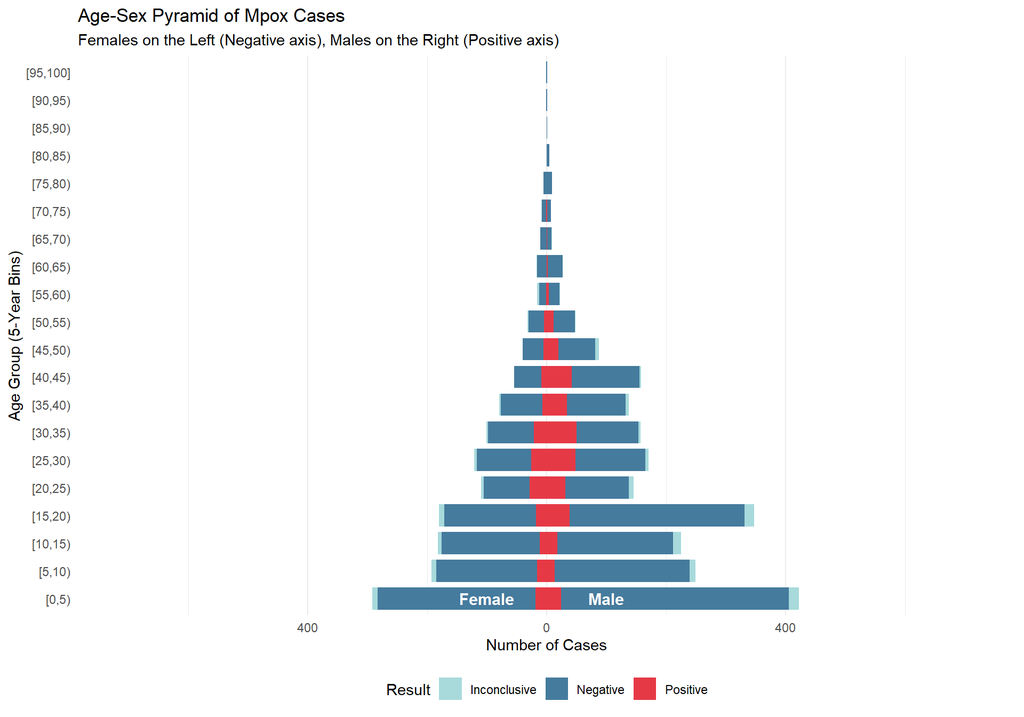

**1. Testing vs. Infection Mismatch:** The chart’s wide blue base reveals that **children (0–15 years)** account for the bulk of suspected cases, yet they test overwhelmingly negative.

**2. The “Red Pillar” of Disease:** Confirmed Mpox cases do not follow the pyramid shape; instead, they form a “column” concentrated in **young adults (20–45 years)**, identifying this group as the true driver of the outbreak.

**3. Male Skew:** Within this confirmed adult hotspot, the red segments are visibly wider on the Male side, reinforcing the finding that young males carry the highest burden of disease.

## 5. Statistical Significance Testing

Visual differences can sometimes be due to random chance. We use statistical tests to confirm if the patterns we see are real.

### A. T-Test for Age

*Null Hypothesis ($H_{0}$):* There is no difference in the average age of Positive vs. Negative patients.

Welch Two Sample T-Test Results

Comparison of Age between Positive and Negative Groups

| Mean Age (Negative) | Mean Age (Positive) | t-statistic | P-value |
| --- | --- | --- | --- |
| 19.796 | 26.512 | −9.615 | 0.000 |

#### Interpretation of the T-Test Results

- **Null Hypothesis ($H_{0}$):** There is no difference in the average age between Positive and Negative patients.
- **P-value:** The p-value is extremely small (< 0.000), which is far below the standard significance level of 0.05.

**Conclusion:** We **reject the Null Hypothesis**. There is strong statistical evidence that the average ages of patients testing positive and negative are genuinely different.

### B. Chi-Square Test for Gender

*Null Hypothesis ($H_{0}$):* Gender and Test Result are independent (not related).

Chi-Squared Test Results

Association between Gender and Test Result

| Chi-Squared Value | P-value | Degrees of Freedom (DF) |
| --- | --- | --- |
| 8.583 | 0.014 | 2 |

#### Interpretation of the Chi-Square Test Results

- **Null Hypothesis ($H_{0}$):** Gender and Test Result are independent (not related).
- **P-value:** 0.01368 (or approximately 0.014).

**Conclusion:** The p-value (0.014) is **less than** the standard significance level of 0.05. This means we have enough evidence to **reject the Null Hypothesis**. **The analysis suggests that a person’s gender is a significant factor in determining their test result**. The proportions of positive and negative results are not the same across the two gender categories within the dataset.

## **Section 2: Place (Geographic & Operational Distribution)**

Mapping the Spread: State-Level Trends and Testing Operations.

## 1. State-Level Burden of Disease

First, we aggregate the data to identify the states with the highest number of suspected and confirmed cases.

Top 10 States by Confirmed Cases

| state | Total_Samples | Confirmed_Cases | Positivity_Rate |
| --- | --- | --- | --- |
| Rivers | 166 | 63 | 38.0 |
| Delta | 176 | 39 | 22.2 |
| Cross River | 141 | 38 | 27.0 |
| Lagos | 266 | 36 | 13.5 |
| Ogun | 317 | 36 | 11.4 |
| Bayelsa | 250 | 34 | 13.6 |
| Akwa Ibom | 238 | 30 | 12.6 |
| Kaduna | 129 | 28 | 21.7 |
| FCT | 152 | 23 | 15.1 |
| Ondo | 132 | 22 | 16.7 |

**Table Analysis & Interpretation:** The summary table highlights a clear distinction between testing volume and disease intensity:

**1. The Epicenter (Rivers State):**

- **Rivers** carries the highest burden of disease with **63 Confirmed Cases**.
- It also records the highest **Positivity Rate (38.0%)**, indicating highly active transmission; nearly 2 out of every 5 samples collected here are positive.

**2. High Volume vs. Lower Yield:**

- **Ogun** and **Lagos** processed the highest volume of samples (317 and 266 respectively), reflecting strong surveillance capacity.
- However, their positivity rates are significantly lower **(11.4% and 13.5%)**, suggesting they are casting a wider net but finding proportionally fewer cases compared to the South-South states.

**3. Regional Clustering:**

The top of the list is dominated by states in the **South-South region** (Rivers, Delta, Cross River, Bayelsa, Akwa Ibom), pointing to a concentrated geographic belt of transmission that requires targeted intervention.

## 2a. Geographic Visualization (Map of Nigeria)

Visualizing the spatial distribution of confirmed cases to identify regional hotspots

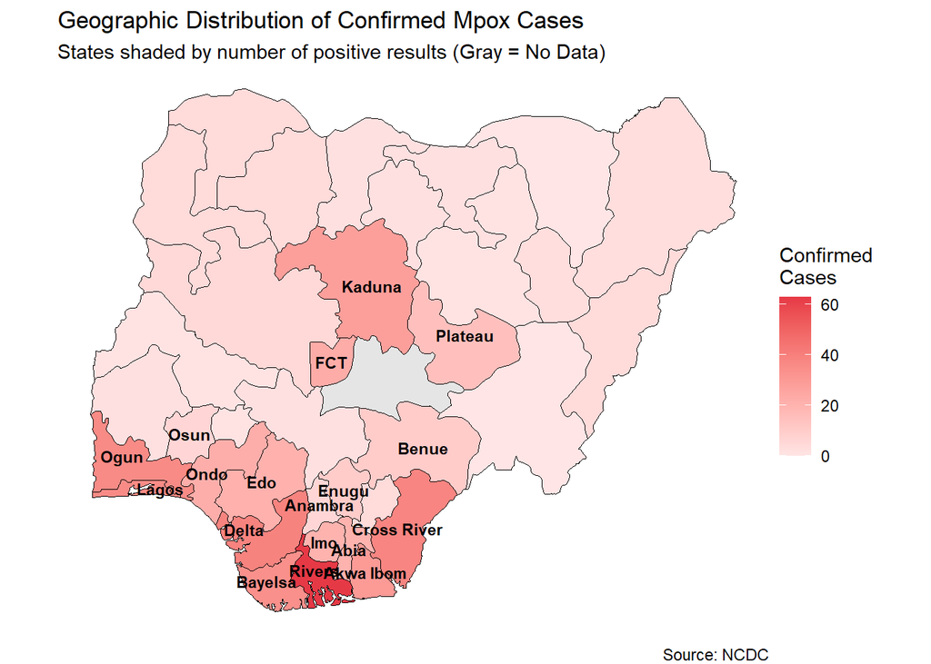

**Map Analysis & Interpretation:** The map visualizes the spatial clustering of the outbreak, revealing a distinct regional pattern:

**1. Primary Hotspot (South-South):** The epicenter of the outbreak is clearly located in the South-South region. **Rivers State** and **Cross River** display the darkest red shading, indicating the highest intensity of confirmed cases (>40-60 cases).

**2. Coastal Transmission:** The virus shows strong circulation along the southern coast, extending into the South-West with significant clusters in Lagos and Ogun.

**3. North-South Divide:** There is a visible disparity in disease burden. While the Southern and North-Central (e.g., **Benue, Kaduna**) regions show active transmission, the far Northern states are largely light pink, indicating significantly fewer confirmed cases.

## 2b. Interactive Spatial Distribution of Confirmed Mpox Cases

Filter by Year

[interactive chart not shown]

## 3. Top Affected States (Bar Chart)

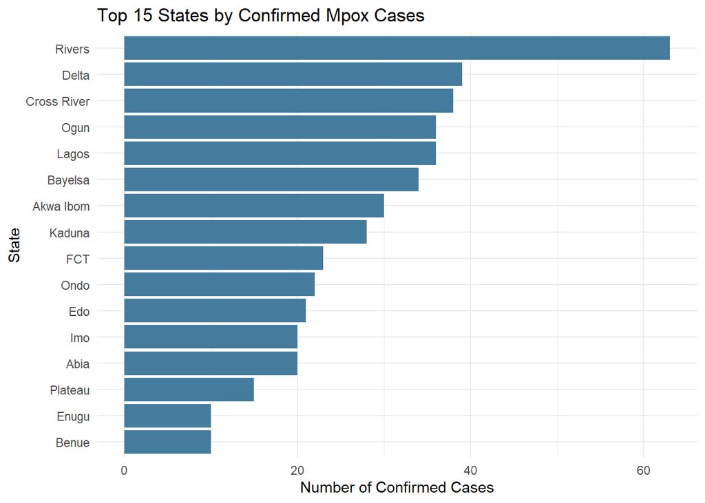

**Chart Interpretation**

**1. Rivers State Dominance: Rivers State** is the undisputed epicenter, recording over 60 confirmed cases—significantly outpacing the rest of the country.

**2. Southern Concentration:** The top of the chart is dominated exclusively by **South-South and South-West states** (Rivers, Delta, Cross River, Ogun, Lagos), confirming the spread is in the southern coastal belt.

## 4. Laboratory Operations Analysis

This section analyzes the operational side. Are certain laboratories overwhelmed? Do different labs see different positivity rates (which might indicate they serve high-transmission catchment areas)?

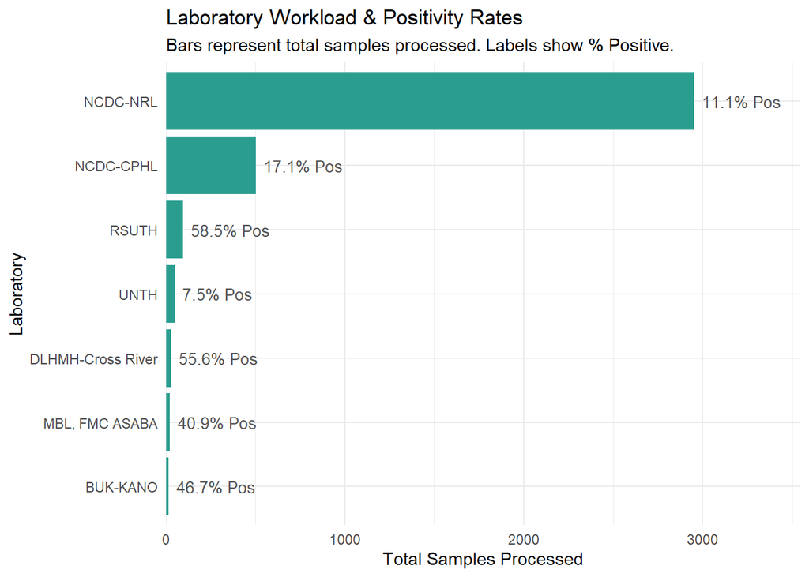

**Interpretation:**

- **Bar Length:** Shows the workload. Longer bars = more samples processed.
- **Percentage Label:** Shows the intensity of transmission in that lab’s region.
- **Note:** If a lab has a very high positivity rate but low sample count, it may be receiving only highly symptomatic referrals.

## **Section 3: Time (Temporal Evolution)**

Analyzing the outbreak over time allows us to determine the current phase of the epidemic (growing, peaking, or declining) and identify seasonal patterns.

## 1. The Epidemic Curve (Epi-Curve)

The Epi-Curve displays the onset of illness over time. We aggregate cases by **Week** to smooth out daily reporting gaps and reveal the underlying trend.

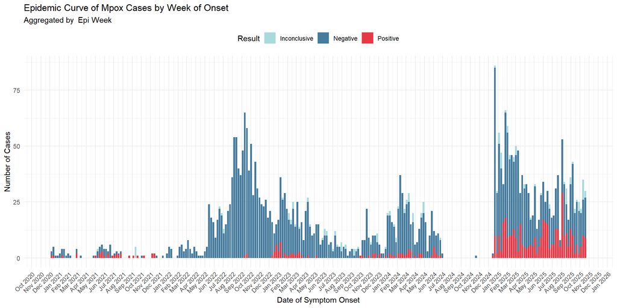

**Chart Analysis & Interpretation:** The temporal evolution reveals three distinct phases of the outbreak:

**1. The “False Alarm” Wave (2022):** The massive spike in late 2022 is dominated by **Blue (Negative)** bars. This reflects a period of intense surveillance and high suspicion but very low actual Mpox transmission.

**2. The Current Outbreak (2025):** The most recent period (starting Jan 2025) shows a distinct shift. While testing volume is high, there is a **substantial cluster of Red (Positive) cases**. This indicates that unlike 2022, the current wave represents a true, active epidemic with widespread transmission.

**3. Seasonality:** The data suggests a cyclical pattern, with surges in reporting often occurring early in the year (Jan-Mar) and mid-year (Aug-Oct), potentially linked to seasonal drivers or reporting campaigns.

## 2. Trend Analysis (Rolling Average)

Smoothing daily fluctuations to reveal the underlying epidemic trajectory.

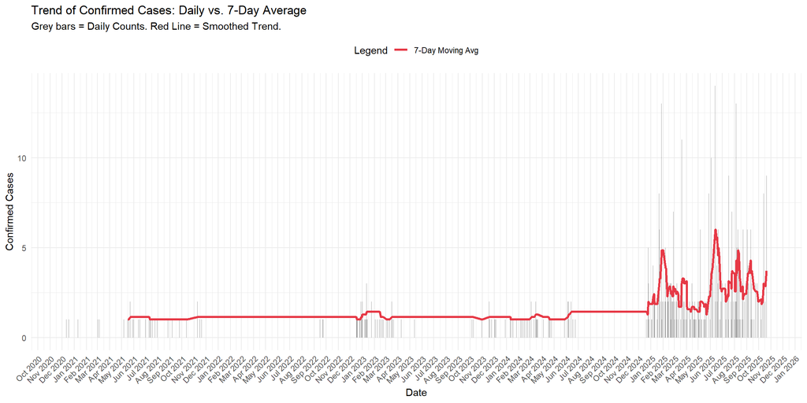

**Chart Analysis & Interpretation:** The 7-day rolling average reveals the true trajectory of the outbreak, filtering out daily fluctuations:

**1. Dormant Phase (2020–2024):** For nearly four years, the red trend line remains flat and near zero, indicating sporadic, isolated cases with no sustained community transmission.

**2. The 2025 Escalation:** A sharp structural break occurs in **January 2025**. The trend line spikes upward and remains elevated, confirming that the current situation is not a series of random events but a sustained outbreak.

**3. Volatility:** The continued fluctuation of the red line in late 2025 suggests that transmission is unstable and ongoing, rather than steadily declining.

## **Section 4: Conclusion & Public Health Recommendations**

## 1. Summary of Epidemiological Findings

This comprehensive analysis of the Mpox outbreak reveals a distinct divergence between surveillance efforts and active disease transmission:

- **Person (Demographics):** There is a critical mismatch in surveillance targeting. While pediatric cases (0–15 years) dominate the testing volume, they yield a very low positivity rate, suggesting a high volume of “false alarm” investigations for common childhood rashes. Conversely, the active burden of disease is concentrated in **young adults (20–40 years)**, with a higher prevalence in **males**.
- **Place (Geography):** The outbreak is not uniformly distributed. The **South-South region** (specifically Rivers, Delta, and Cross River) represents the primary epicenter with the highest positivity rates. High testing volumes in Lagos and Ogun indicate strong surveillance capacity but lower comparative transmission intensity.
- **Time (Trends):** The epidemic trajectory shifted significantly in **January 2025**. Unlike the sporadic reporting seen in previous years, 2025 marks a sustained, active outbreak phase requiring immediate intervention.

## 2. Public Health Recommendations

Based on these findings, we recommend the following evidence-based actions:

### **A. Refine Case Definitions & Surveillance Strategies**

- **The Issue:** The surveillance system is currently overwhelmed by negative pediatric samples (likely Varicella/Chickenpox).
- **Recommendation:** Update the *Suspected Case Definition* to include more specific exclusion criteria for common childhood exanthems. Train clinicians in high-volume pediatric centers to clinically differentiate Mpox from Varicella before collecting samples. This will reduce laboratory backlog and conserve resources.

### **B. Target Risk Communication to the “Red Pillar”**

- **The Issue:** The “Red Pillar” of confirmed cases is composed of young men who may not perceive themselves as the primary risk group due to the high visibility of pediatric testing.
- **Recommendation:** Launch targeted behavioral change communication campaigns focused on **Men aged 20–40**. Messaging should address risk factors specific to this demographic rather than general population messaging.

### **C. Strategic Resource Allocation**

- **The Issue:** Resources may be spread too thinly across the country.
- **Recommendation:** Shift from a nationwide distribution model to a **risk-based allocation model**. Prioritize vaccines, therapeutics, and advanced PPE for the **South-South epicenter (Rivers, Delta, Cross River)** to break the chain of transmission at the source.

*Report generated on 2026-03-14*  
*Data Source: NCDC*